# US Flights in 2008 and comparisons with other years

## by Duc Vu

- Preliminary Wrangling
- Univariate Exploration
- Insights and Conclusions
- Bivariate Exploration
- Insights and Conclusions
- Multivariate Exploration
- Insights and Conclusions

## Preliminary Wrangling

The datasets are obtained through the [Statistical Computing Statistical Graphics](http://stat-computing.org/dataexpo/2009/the-data.html) and contain US flights information for 1987-2008.

Chosen for this project are flights information for five year intervals (1988, 1993, 1998, 2003, 2008). The main data analysis and visualisations will be conducted for Year 2008. The project contains three sections - Univariate, Bivariate, and Multivariate Exploration.

Several visualisations and insights will combine 2008 with the years mentioned above. The files `Flights2008.csv` and other years contain the most important information about the flights, including scheduled and actual departure times, arrival times, cancellations, delays, etc..

In addition to the flight information files, the carrier airline, origin and destination locations information are located in seperate files - `carriers.csv` and `airport.csv` respectively.

```python
# import all packages and set plots to be embedded inline
import numpy as np
import pandas as pd
import matplotlib.pyplot as plt
import seaborn as sb
import datetime as dt

%matplotlib inline
```

**Firstly**, the datasets containing the vital flight information `FlightsYYYY.csv` for different years are read into dataframes.

```python
# Loading Original Flight Information Dataset
f2008 = pd.read_csv("./Dataset/Flights2008.csv", encoding="utf-8")
```

For years 1988, 1993, 1998, and 2003, the following columns will be loaded into a DF for comparison analysis: Year, Month, DayofMonth, ArrDelay, DepDelay, and Cancelled.

```python
col_pre_2008 = ["Year", "Month", "DayofMonth", "ArrDelay", "DepDelay", "Cancelled"]
```

```python
f1988 = pd.read_csv("./Dataset/Flights1988.csv", encoding="utf-8", usecols = col_pre_2008)
f1993 = pd.read_csv("./Dataset/Flights1993.csv", encoding="utf-8", usecols = col_pre_2008)
f1998 = pd.read_csv("./Dataset/Flights1998.csv", encoding="utf-8", usecols = col_pre_2008)
f2003 = pd.read_csv("./Dataset/Flights2003.csv", encoding="utf-8", usecols = col_pre_2008)
```

```python
#f1988.shape, f1993.shape, f1998.shape, f2003.shape,
f2008.shape
```

```
(7009728, 29)
```

```python
# Column labels
f2008.columns
```

```
Index(['Year', 'Month', 'DayofMonth', 'DayOfWeek', 'DepTime', 'CRSDepTime',
       'ArrTime', 'CRSArrTime', 'UniqueCarrier', 'FlightNum', 'TailNum',
       'ActualElapsedTime', 'CRSElapsedTime', 'AirTime', 'ArrDelay',
       'DepDelay', 'Origin', 'Dest', 'Distance', 'TaxiIn', 'TaxiOut',
       'Cancelled', 'CancellationCode', 'Diverted', 'CarrierDelay',
       'WeatherDelay', 'NASDelay', 'SecurityDelay', 'LateAircraftDelay'],
      dtype='object')
```

```python
f1988.columns
```

```
Index(['Year', 'Month', 'DayofMonth', 'ArrDelay', 'DepDelay', 'Cancelled'], dtype='object')
```

As each dataframe contain large amounts of data, it is better to keep the dataframes seperate for faster running time rather than combining into one large dataframe.

```python
pd.set_option("display.max_column", 29)
f2008.sample(5)
```

|  | Year | Month | DayofMonth | DayOfWeek | DepTime | CRSDepTime | ArrTime | CRSArrTime | UniqueCarrier | FlightNum | TailNum | ActualElapsedTime | CRSElapsedTime | AirTime | ArrDelay | DepDelay | Origin | Dest | Distance | TaxiIn | TaxiOut | Cancelled | CancellationCode | Diverted | CarrierDelay | WeatherDelay | NASDelay | SecurityDelay | LateAircraftDelay |
| --- | --- | --- | --- | --- | --- | --- | --- | --- | --- | --- | --- | --- | --- | --- | --- | --- | --- | --- | --- | --- | --- | --- | --- | --- | --- | --- | --- | --- | --- |
| 5884551 | 2008 | 10 | 26 | 7 | 1255.0 | 1255 | 2128.0 | 2135 | AS | 858 | N584AS | 333.0 | 340.0 | 314.0 | -7.0 | 0.0 | OGG | SEA | 2640 | 4.0 | 15.0 | 0 | NaN | 0 | NaN | NaN | NaN | NaN | NaN |
| 2066899 | 2008 | 4 | 19 | 6 | 1211.0 | 1215 | 1421.0 | 1448 | US | 1726 | N458UW | 130.0 | 153.0 | 114.0 | -27.0 | -4.0 | MCO | PHL | 861 | 7.0 | 9.0 | 0 | NaN | 0 | NaN | NaN | NaN | NaN | NaN |
| 2855795 | 2008 | 5 | 16 | 5 | 1845.0 | 1845 | 1926.0 | 1932 | 9E | 5665 | 80139E | 101.0 | 107.0 | 84.0 | -6.0 | 0.0 | FNT | MSP | 491 | 6.0 | 11.0 | 0 | NaN | 0 | NaN | NaN | NaN | NaN | NaN |
| 3925904 | 2008 | 7 | 25 | 5 | 1122.0 | 1125 | 1905.0 | 1913 | DL | 1538 | N647DL | 283.0 | 288.0 | 261.0 | -8.0 | -3.0 | PDX | ATL | 2172 | 8.0 | 14.0 | 0 | NaN | 0 | NaN | NaN | NaN | NaN | NaN |
| 1747521 | 2008 | 3 | 26 | 3 | 824.0 | 825 | 1015.0 | 1038 | CO | 345 | N76502 | 171.0 | 193.0 | 156.0 | -23.0 | -1.0 | CLE | IAH | 1091 | 5.0 | 10.0 | 0 | NaN | 0 | NaN | NaN | NaN | NaN | NaN |

**Secondly**, two seperate files containing carrier information (`carriers.csv`) and airport locations in the US (`airports.csv`) are added.

```python
carriers = pd.read_csv("./Dataset/carriers.csv")
carriers.head()
```

|  | Code | Description |
| --- | --- | --- |
| 0 | 02Q | Titan Airways |
| 1 | 04Q | Tradewind Aviation |
| 2 | 05Q | Comlux Aviation, AG |
| 3 | 06Q | Master Top Linhas Aereas Ltd. |
| 4 | 07Q | Flair Airlines Ltd. |

```python
carriers.shape[0]
```

```
1491
```

```python
airports = pd.read_csv("./Dataset/airports.csv")
airports.head()
```

|  | iata | airport | city | state | country | lat | long |
| --- | --- | --- | --- | --- | --- | --- | --- |
| 0 | 00M | Thigpen | Bay Springs | MS | USA | 31.953765 | -89.234505 |
| 1 | 00R | Livingston Municipal | Livingston | TX | USA | 30.685861 | -95.017928 |
| 2 | 00V | Meadow Lake | Colorado Springs | CO | USA | 38.945749 | -104.569893 |
| 3 | 01G | Perry-Warsaw | Perry | NY | USA | 42.741347 | -78.052081 |
| 4 | 01J | Hilliard Airpark | Hilliard | FL | USA | 30.688012 | -81.905944 |

**Thirdly**, the carrier names from the `carriers` DF are combined with the all the flights DF. Before combining, create a copy of each DF.

```python
# Create a copy of each dataframe
f2008_clean = f2008.copy()
```

```python
f1988_clean = f1988.copy()
f1993_clean = f1993.copy()
f1998_clean = f1998.copy()
f2003_clean = f2003.copy()
```

```python
# Combining carriers to DF
f2008_clean = pd.merge(f2008_clean, carriers, left_on = "UniqueCarrier", right_on = "Code", how = "left")
```

```python
f2008_clean.columns
```

```
Index(['Year', 'Month', 'DayofMonth', 'DayOfWeek', 'DepTime', 'CRSDepTime',
       'ArrTime', 'CRSArrTime', 'UniqueCarrier', 'FlightNum', 'TailNum',
       'ActualElapsedTime', 'CRSElapsedTime', 'AirTime', 'ArrDelay',
       'DepDelay', 'Origin', 'Dest', 'Distance', 'TaxiIn', 'TaxiOut',
       'Cancelled', 'CancellationCode', 'Diverted', 'CarrierDelay',
       'WeatherDelay', 'NASDelay', 'SecurityDelay', 'LateAircraftDelay',
       'Code', 'Description'],
      dtype='object')
```

**Fourthly**, the airport city and states from the `airport` DF are merged with the flights DF for origin and destinations. Before merging, only the iata code, city and state are needed to be added.

```python
airports_mod = airports[["iata", "city", "state"]]
airports_mod.head()
```

|  | iata | city | state |
| --- | --- | --- | --- |
| 0 | 00M | Bay Springs | MS |
| 1 | 00R | Livingston | TX |
| 2 | 00V | Colorado Springs | CO |
| 3 | 01G | Perry | NY |
| 4 | 01J | Hilliard | FL |

```python
# Combining origin locations for 2008
f2008_clean = pd.merge(f2008_clean, airports_mod, left_on = "Origin", right_on = "iata", how = "left")
```

```python
# Combining destination locations for 2008
f2008_clean = pd.merge(f2008_clean, airports_mod, left_on = "Dest", right_on = "iata", how = "left")
```

```python
f2008_clean.columns
```

```
Index(['Year', 'Month', 'DayofMonth', 'DayOfWeek', 'DepTime', 'CRSDepTime',
       'ArrTime', 'CRSArrTime', 'UniqueCarrier', 'FlightNum', 'TailNum',
       'ActualElapsedTime', 'CRSElapsedTime', 'AirTime', 'ArrDelay',
       'DepDelay', 'Origin', 'Dest', 'Distance', 'TaxiIn', 'TaxiOut',
       'Cancelled', 'CancellationCode', 'Diverted', 'CarrierDelay',
       'WeatherDelay', 'NASDelay', 'SecurityDelay', 'LateAircraftDelay',
       'Code', 'Description', 'iata_x', 'city_x', 'state_x', 'iata_y',
       'city_y', 'state_y'],
      dtype='object')
```

### Structure of the dataset

```python
f2008_clean.info()
```

```
<class 'pandas.core.frame.DataFrame'>
Int64Index: 7009728 entries, 0 to 7009727
Data columns (total 37 columns):
Year                 int64
Month                int64
DayofMonth           int64
DayOfWeek            int64
DepTime              float64
CRSDepTime           int64
ArrTime              float64
CRSArrTime           int64
UniqueCarrier        object
FlightNum            int64
TailNum              object
ActualElapsedTime    float64
CRSElapsedTime       float64
AirTime              float64
ArrDelay             float64
DepDelay             float64
Origin               object
Dest                 object
Distance             int64
TaxiIn               float64
TaxiOut              float64
Cancelled            int64
CancellationCode     object
Diverted             int64
CarrierDelay         float64
WeatherDelay         float64
NASDelay             float64
SecurityDelay        float64
LateAircraftDelay    float64
Code                 object
Description          object
iata_x               object
city_x               object
state_x              object
iata_y               object
city_y               object
state_y              object
dtypes: float64(14), int64(10), object(13)
memory usage: 2.0+ GB
```

The following variables (or columns) require a change in data types:

- `Cancelled` to a Boolean
- `Diverted` to a Boolean
- `DepTime`, `CRSDepTime`, `ArrTime`, `CRSArrTime` to an integer for regular expressions manipulation later

```python
f2008_clean.Cancelled.replace({1: True, 0: False}, inplace=True)
f2008_clean.Diverted.replace({1: True, 0: False}, inplace=True)
```

```python
f1988_clean.Cancelled.replace({1: True, 0: False}, inplace=True)
f1993_clean.Cancelled.replace({1: True, 0: False}, inplace=True)
f1998_clean.Cancelled.replace({1: True, 0: False}, inplace=True)
f2003_clean.Cancelled.replace({1: True, 0: False}, inplace=True)
```

```python
f2008_clean.Cancelled.value_counts()
```

```
False    6872294
True      137434
Name: Cancelled, dtype: int64
```

```python
# Change datatypes to integer
time_ls = ["DepTime", "CRSDepTime", "ArrTime", "CRSArrTime"]

for time in time_ls:
    f2008_clean[time] = pd.Series(f2008_clean[time], dtype="Int64")
```

In addition, the values in the `CancellationCode` will be replaced with the actual reason instead of a code. Prior to 2003, the reasons were not recorded. Therefore, only the flights in 2008 will be affected by this analysis.

```python
f2008_clean.CancellationCode = f2008_clean.CancellationCode.astype(object)
f2008_clean.CancellationCode.value_counts()
```

```
B    54904
A    54330
C    28188
D       12
Name: CancellationCode, dtype: int64
```

```python
cancellation_dict = {"A": "carrier", "B": "weather", "C": "NAS", "D": "security"}
f2008_clean.CancellationCode = f2008_clean.CancellationCode.replace(cancellation_dict)
f2008_clean.CancellationCode.value_counts()
```

```
weather     54904
carrier     54330
NAS         28188
security       12
Name: CancellationCode, dtype: int64
```

Furthermore, US Airways Inc. and America West Airlines Inc. merged to form US Airways Inc. from September 2005. Thus, prior to 2005, the names of the two airlines will be as they are, and after 2005, only US Airways Inc. exist.

```python
f2008_clean.Description.value_counts().head()
```

```
Southwest Airlines Co.          1201754
American Airlines Inc.           604885
Skywest Airlines Inc.            567159
American Eagle Airlines Inc.     490693
US Airways Inc.                  453589
Name: Description, dtype: int64
```

```python
# Prior to 2005, the two airlines will be under their own names (removing the "(Merged...)")
airline_dict = {"US Airways Inc. (Merged with America West 9/05. Reporting for both starting 10/07.)": "US Airways Inc.",
               "America West Airlines Inc. (Merged with US Airways 9/05. Stopped reporting 10/07.)": "America West Airlines Inc."}
```

```python
# After 2005, both airlines merged and only formed "US Airways Inc."
f2008_clean.Description = f2008_clean.Description.replace(airline_dict)
f2008_clean.Description.value_counts()
```

```
Southwest Airlines Co.          1201754
American Airlines Inc.           604885
Skywest Airlines Inc.            567159
American Eagle Airlines Inc.     490693
US Airways Inc.                  453589
Delta Air Lines Inc.             451931
United Air Lines Inc.            449515
Expressjet Airlines Inc.         374510
Northwest Airlines Inc.          347652
Continental Air Lines Inc.       298455
Atlantic Southeast Airlines      280575
Pinnacle Airlines Inc.           262208
AirTran Airways Corporation      261684
Mesa Airlines Inc.               254930
Comair Inc.                      197607
JetBlue Airways                  196091
Alaska Airlines Inc.             151102
Frontier Airlines Inc.            95762
Hawaiian Airlines Inc.            61826
Aloha Airlines Inc.                7800
Name: Description, dtype: int64
```

The `DepTime`, `CRSDepTime`, `ArrTime` and `CRSArrTime` requires padding as the timings are either three or four digits long. For consistency, the timings before 1000 will be padded with a zero in front. For example 737 will become 0737.

```python
# First, padding of 0 is required for timings with 3 digit widths, i.e. timings before 1000.
# Method below requires the timings to be changed to object type
f2008_clean.CRSDepTime = f2008_clean.CRSDepTime.astype(str).str.zfill(4)
f2008_clean.CRSDepTime[0:5]
```

```
0    1955
1    0735
2    0620
3    0930
4    1755
Name: CRSDepTime, dtype: object
```

```python
f2008_clean.describe()
```

|  | Year | Month | DayofMonth | DayOfWeek | DepTime | ArrTime | CRSArrTime | FlightNum | ActualElapsedTime | CRSElapsedTime | AirTime | ArrDelay | DepDelay | Distance | TaxiIn | TaxiOut | CarrierDelay | WeatherDelay | NASDelay | SecurityDelay | LateAircraftDelay |
| --- | --- | --- | --- | --- | --- | --- | --- | --- | --- | --- | --- | --- | --- | --- | --- | --- | --- | --- | --- | --- | --- |
| count | 7009728.0 | 7.009728e+06 | 7.009728e+06 | 7.009728e+06 | 6.873482e+06 | 6.858079e+06 | 7.009728e+06 | 7.009728e+06 | 6.855029e+06 | 7.008884e+06 | 6.855029e+06 | 6.855029e+06 | 6.873482e+06 | 7.009728e+06 | 6.858079e+06 | 6.872670e+06 | 1.524735e+06 | 1.524735e+06 | 1.524735e+06 | 1.524735e+06 | 1.524735e+06 |
| mean | 2008.0 | 6.375130e+00 | 1.572801e+01 | 3.924182e+00 | 1.333830e+03 | 1.481258e+03 | 1.494801e+03 | 2.224200e+03 | 1.273224e+02 | 1.288668e+02 | 1.040186e+02 | 8.168452e+00 | 9.972570e+00 | 7.263870e+02 | 6.860852e+00 | 1.645305e+01 | 1.577206e+01 | 3.039031e+00 | 1.716462e+01 | 7.497434e-02 | 2.077098e+01 |
| std | 0.0 | 3.406737e+00 | 8.797068e+00 | 1.988259e+00 | 4.780689e+02 | 5.052251e+02 | 4.826728e+02 | 1.961716e+03 | 7.018731e+01 | 6.940974e+01 | 6.743980e+01 | 3.850194e+01 | 3.531127e+01 | 5.621018e+02 | 4.933649e+00 | 1.133280e+01 | 4.009912e+01 | 1.950287e+01 | 3.189495e+01 | 1.837940e+00 | 3.925964e+01 |
| min | 2008.0 | 1.000000e+00 | 1.000000e+00 | 1.000000e+00 | 1.000000e+00 | 1.000000e+00 | 0.000000e+00 | 1.000000e+00 | 1.200000e+01 | -1.410000e+02 | 0.000000e+00 | -5.190000e+02 | -5.340000e+02 | 1.100000e+01 | 0.000000e+00 | 0.000000e+00 | 0.000000e+00 | 0.000000e+00 | 0.000000e+00 | 0.000000e+00 | 0.000000e+00 |
| 25% | 2008.0 | 3.000000e+00 | 8.000000e+00 | 2.000000e+00 | 9.280000e+02 | 1.107000e+03 | 1.115000e+03 | 6.220000e+02 | 7.700000e+01 | 8.000000e+01 | 5.500000e+01 | -1.000000e+01 | -4.000000e+00 | 3.250000e+02 | 4.000000e+00 | 1.000000e+01 | 0.000000e+00 | 0.000000e+00 | 0.000000e+00 | 0.000000e+00 | 0.000000e+00 |
| 50% | 2008.0 | 6.000000e+00 | 1.600000e+01 | 4.000000e+00 | 1.325000e+03 | 1.512000e+03 | 1.517000e+03 | 1.571000e+03 | 1.100000e+02 | 1.100000e+02 | 8.600000e+01 | -2.000000e+00 | -1.000000e+00 | 5.810000e+02 | 6.000000e+00 | 1.400000e+01 | 0.000000e+00 | 0.000000e+00 | 6.000000e+00 | 0.000000e+00 | 0.000000e+00 |
| 75% | 2008.0 | 9.000000e+00 | 2.300000e+01 | 6.000000e+00 | 1.728000e+03 | 1.909000e+03 | 1.907000e+03 | 3.518000e+03 | 1.570000e+02 | 1.590000e+02 | 1.320000e+02 | 1.200000e+01 | 8.000000e+00 | 9.540000e+02 | 8.000000e+00 | 1.900000e+01 | 1.600000e+01 | 0.000000e+00 | 2.100000e+01 | 0.000000e+00 | 2.600000e+01 |
| max | 2008.0 | 1.200000e+01 | 3.100000e+01 | 7.000000e+00 | 2.400000e+03 | 2.400000e+03 | 2.400000e+03 | 9.743000e+03 | 1.379000e+03 | 1.435000e+03 | 1.350000e+03 | 2.461000e+03 | 2.467000e+03 | 4.962000e+03 | 3.080000e+02 | 4.290000e+02 | 2.436000e+03 | 1.352000e+03 | 1.357000e+03 | 3.920000e+02 | 1.316000e+03 |

### Main features of interest in the dataset

### The following features in the dataset will help support the questions of interest as outlined above.

The main features (or columns) of interest are:

- `Year`
- `Month`
- `Day` - renamed from `DayofMonth`
- `DayOfWeek`
- `DepTime` - actual depature time (local, in hhmm)
- `CRSDepTime` - scheduled departure time (local, in hhmm)
- `ArrTime` - actual arrival time (in hhmm)
- `CRSArrTime` - scheduled arrival time (local, in hhmm)
- `ActualElapsedTime` - actual flight elapsed time (in minutes)
- `CRSElapsedTime` - scheduled flight elapsed time (in minutes)
- `AirTime` - time of aircraft in air (in minutes)
- `ArrDelay` - arrival delay (in minutes)
- `DepDelay` - departure delay (in minutes)
- `Distance` - in miles
- `Cancelled` - was the flight cancelled?
- `CancellationReason` - reason for cancellation. This column is renamed from `CancellationCode` and the appropriate reason is shown.
- `Diverted` - was the flight diverted?
- `CarrierDelay`, `WeatherDelay`, `NASDelay`, `SecurityDelay`, `LateAircraftDelay` - in minutes
- `Airline` - name of airline carrier, renamed from `Description` column
- `Origin_city` and `Origin_state` - location of origin of flight, renamed from `city_x` and `state_x`
- `Dest_city` and `Dest_state` - location of origin of flight, renamed from `city_y` and `state_y`

```python
# Rename columns
f2008_clean.rename(columns={"DayofMonth": "Day", "city_x": "Origin_city", "state_x": "Origin_state",
                            "city_y": "Dest_city", "state_y": "Dest_state", "Description": "Airline",
                            "CancellationCode": "CancellationReason"}, inplace = True)
```

```python
# Dropped unnecessary columns
columns_drop = ['UniqueCarrier', 'FlightNum', 'TailNum', 'Origin', 'Dest',
                'TaxiIn', 'TaxiOut', 'Code', 'iata_x', 'iata_y']
f2008_clean.drop(columns_drop, axis = 1, inplace = True)
```

```python
f2008_clean.columns
```

```
Index(['Year', 'Month', 'Day', 'DayOfWeek', 'DepTime', 'CRSDepTime', 'ArrTime',
       'CRSArrTime', 'ActualElapsedTime', 'CRSElapsedTime', 'AirTime',
       'ArrDelay', 'DepDelay', 'Distance', 'Cancelled', 'CancellationReason',
       'Diverted', 'CarrierDelay', 'WeatherDelay', 'NASDelay', 'SecurityDelay',
       'LateAircraftDelay', 'Airline', 'Origin_city', 'Origin_state',
       'Dest_city', 'Dest_state'],
      dtype='object')
```

```python
f2008_clean.shape
```

```
(7009728, 27)
```

```python
f2008_clean.info()
```

[output not shown]

## Univariate Exploration

In this section of univariate exploration, the year **2008** will be explored. First, the visualisations to each question along with comments on it will be given. Then at the end of the section, interesting insights, interpretations and questions will be provided.

The distribution of flights from the following variables are explored individually:

1. `DayofMonth` and `Month` - how does the number of flights vary day by day?
2. `Month` - are flights more common in a particular month compared to another?
3. `DayOfWeek` - are there more or fewer flights scheduled in a particular day of the week?
4. `DepDelay` (calculated from `DepTime` and `CRSDepTime`) - what is the distribution of the difference between actual and scheduled depature time?
5. `ArrDelay` (calculated from `ArrTime` and `CRSArrTime`) - what is the distribution of the difference between actual and scheduled arrival time?
6. `CRSDepTime` - are there more flights scheduled at a particular hour of the day?
7. `AirTime` - what is the distribution of the duration of flights?
8. `Distance` - what is the distribution of distances travelled by aircrafts?
9. `Cancelled` and `CancellationReason` - what is the proportion of flights cancelled? What are the reasons for cancellations?
10. `Diverted` - what is the proportion of flights diverted?
11. `Airline` - which airline has the most and least flights scheduled?
12. `Origin_city` - what are the top 10 cities with the most flights scheduled to take off?
13. `Origin_state` - what are the top 3 states with the most flights scheduled to take off? What are the top 3 states with the least flights scheduled to take off?

Jump to Univariate Insights and Interpretations

#### `DayofMonth` and `Month`

**How does the number of flights vary day by day?**

First, create new column in DF in the form of a datetime object. Then, use groupby method to find the total numbers of flights by day and plot a time series.

```python
import matplotlib.dates as mdates
```

```python
f2008_clean["DateTime"] = pd.to_datetime(f2008_clean[["Year", "Month", "Day"]])
```

```python
flight_by_day = f2008_clean.groupby("DateTime").count()
```

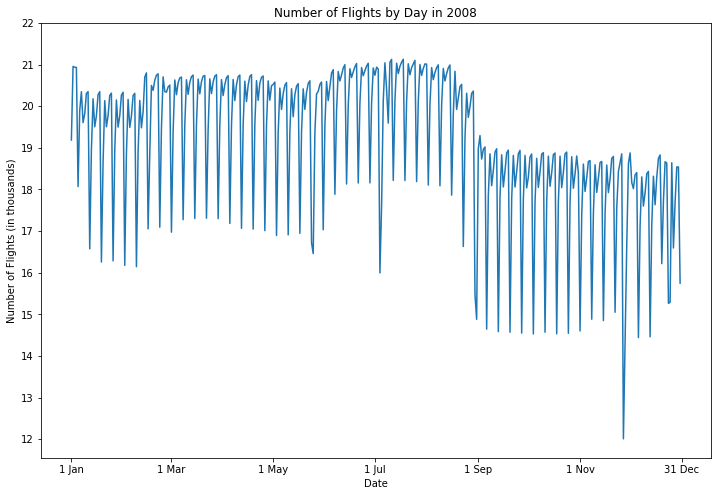

```python
plt.figure(figsize = (12, 8))
plt.errorbar(flight_by_day.index, flight_by_day.Year)

plt.title("Number of Flights by Day in 2008")
plt.xlabel("Date")
plt.ylabel("Number of Flights (in thousands)")
ticks = np.array([n for n in range (12, 23)])
plt.yticks(ticks * 1000, ticks)

# Change the x-axis label
ax = plt.gca().get_xticks()
plt.xticks(ax, ["1 Jan", "1 Mar", "1 May", "1 Jul", "1 Sep", "1 Nov", "31 Dec"]);
```

```python
flight_by_day[flight_by_day.Year == flight_by_day.Year.min()]
```

| DateTime | Year | Month | Day | DayOfWeek | DepTime | CRSDepTime | ArrTime | CRSArrTime | ActualElapsedTime | CRSElapsedTime | AirTime | ArrDelay | DepDelay | Distance | Cancelled | CancellationReason | Diverted | CarrierDelay | WeatherDelay | NASDelay | SecurityDelay | LateAircraftDelay | Airline | Origin_city | Origin_state | Dest_city | Dest_state |
| --- | --- | --- | --- | --- | --- | --- | --- | --- | --- | --- | --- | --- | --- | --- | --- | --- | --- | --- | --- | --- | --- | --- | --- | --- | --- | --- | --- |
| 2008-11-27 | 12008 | 12008 | 12008 | 12008 | 11981 | 12008 | 11978 | 12008 | 11961 | 12008 | 11961 | 11961 | 11981 | 12008 | 12008 | 28 | 12008 | 950 | 950 | 950 | 950 | 950 | 12008 | 12000 | 12000 | 12000 | 12000 |

Interestingly, the number of flights follows a spike drop pattern with certain days experiencing a huge drop, and appearing in regular intervals. This drop could be further investigated on what day of the week experiences a lower number of flights. There is a particular sharp drop on 27 November 2008.

To check if there is any pattern and to remove noise, a moving average of 7 days (a week) is computed and plotted. Pandas' rolling function allows to calculate the moving average.

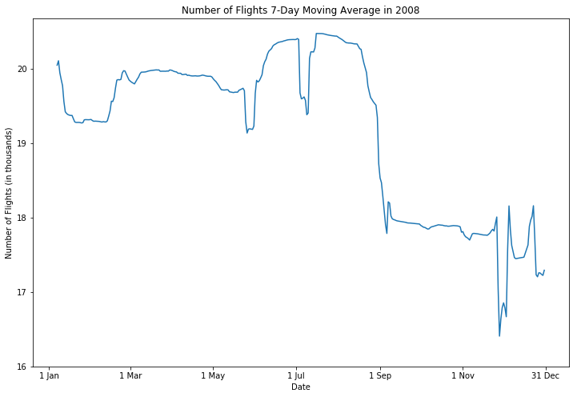

```python
moving_average_7 = flight_by_day.Year.rolling(window = 7).mean()

plt.figure(figsize = (12, 8))
plt.errorbar(flight_by_day.index, moving_average_7)
plt.title("Number of Flights 7-Day Moving Average in 2008")
plt.xlabel("Date")
plt.ylabel("Number of Flights (in thousands)")
ticks0 = np.array([n for n in range (16, 21)])
plt.yticks(ticks0 * 1000, ticks0);

ax = plt.gca().get_xticks()
plt.xticks(ax, ["1 Jan", "1 Mar", "1 May", "1 Jul", "1 Sep", "1 Nov", "31 Dec"]);
```

The plot does not reveal any particular pattern. However, it can be seen that in February there is a slight dip before rising and staying fairly constant between March and May. The peaks in the number of flights are in July and August, and towards the end of August and beginning of September, there is a noticable significant fall in the number of flights.

#### `Month`

**Are flights more common in a particular month compared to another?**

Is summer and during festive periods in December popular times for people to go on holidays, therefore likely to increase the number of flights scheduled?

```python
month2008 = f2008_clean.Month.value_counts()
month2008
```

```
7     627931
3     616090
8     612279
6     608665
5     606293
1     605765
4     598126
2     569236
10    556205
12    544958
9     540908
11    523272
Name: Month, dtype: int64
```

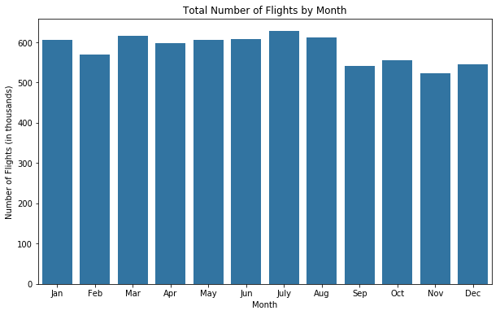

```python
plt.figure(figsize = (10, 6))

# Set standard seaborn color of bar charts to single colour
base_color = sb.color_palette()[0]

# Plot qualitative variable by Month
sb.countplot(data = f2008_clean, x = "Month", color = base_color)
plt.title("Total Number of Flights by Month")
plt.ylabel("Number of Flights (in thousands)")

# Change tick labels for readability
ticks1 = np.array([n for n in range(0, 601, 100)])
plt.yticks(ticks1 * 1000, ticks1)
months = ["Jan", "Feb", "Mar", "Apr", "May", "Jun", "July", "Aug", "Sep", "Oct", "Nov", "Dec"]
ax = plt.gca().get_xticks()
plt.xticks(ax, months);
```

```python
months_dict = {1: "Jan", 2: "Feb", 3: "Mar", 4: "Apr", 5: "May", 6: "Jun",
               7: "July", 8: "Aug", 9: "Sep", 10: "Oct", 11: "Nov", 12: "Dec"}
months_idx = month2008.index.map(months_dict)
```

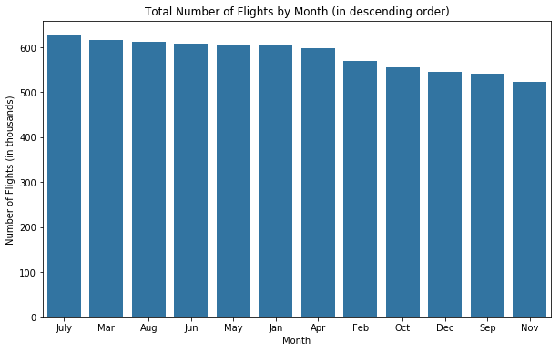

```python
# Plot qualitative variable in descending order of flights
plt.figure(figsize = (10, 6))
sb.countplot(data = f2008_clean, x = "Month", color = base_color, order = month2008.index)

plt.title("Total Number of Flights by Month (in descending order)")
plt.ylabel("Number of Flights (in thousands)")

# Change tick labels for readability
plt.yticks(ticks1 * 1000, ticks1);
ax = plt.gca().get_xticks()
plt.xticks(ax, months_idx);
```

```python
(f2008_clean.Month.value_counts().values[0] - f2008_clean.Month.value_counts().values[-1])/f2008_clean.Month.value_counts().values[0]
```

```
0.1666727713713768
```

In 2008, the months with the most flights scheduled are July, March, and August. The month with the least flight scheduled is November. The difference between the lowest and highest number of flights scheduled by month is almost 100,000 flights or around 17% lower. Interestingly, December has the third least number flights scheduled.

#### `DayOfWeek`

**Are there more or fewer flights scheduled in a particular day of the week?**

Do we expect more people to take flights during the weekend for a weekend getaway compared to during weekdays? This directly helps answer the previous visualisation on number of flights by day, analysing why there is a regular steep drop on particular days.

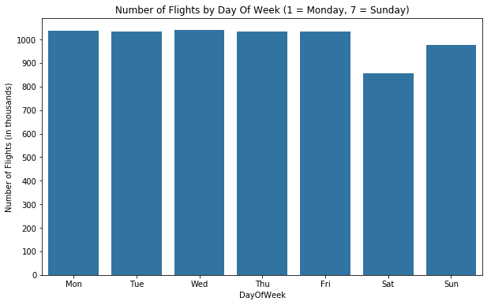

```python
fig = plt.figure(figsize = (10, 6))
sb.countplot(f2008_clean.DayOfWeek, color = base_color)

plt.title("Number of Flights by Day Of Week (1 = Monday, 7 = Sunday)")
plt.ylabel("Number of Flights (in thousands)")
ticks2 = np.array([n for n in range(0, 1001, 100)])
plt.yticks(ticks2 * 1000, ticks2)

# Get axis location to change to name of days of the week
ax = plt.gca().get_xticks()
plt.xticks(ax, ["Mon", "Tue", "Wed", "Thu", "Fri", "Sat", "Sun"]);
```

This gives an unexpected and interesting distribution. During the weekdays (Mondays to Fridays), the number of flights scheduled are very similar. On the weekends (Saturdays and Sundays), the number of flights are visibly lower, with Saturdays experiencing a significant dip (up to 17% lower). Perhaps, the lower number of flights on Saturday is contributing to the steep drop seen from the first visualisation of number of flights by day.

```python
f2008_clean.DayOfWeek.value_counts()
```

```
3    1039665
1    1036201
5    1035166
4    1032224
2    1032049
7     976887
6     857536
Name: DayOfWeek, dtype: int64
```

#### `DepDelay`

**What is the distribution of the difference between actual and scheduled depature time?**

```python
# First remove the flights that have NaN values
departure_delay = f2008_clean[f2008_clean.DepDelay.notnull()]
```

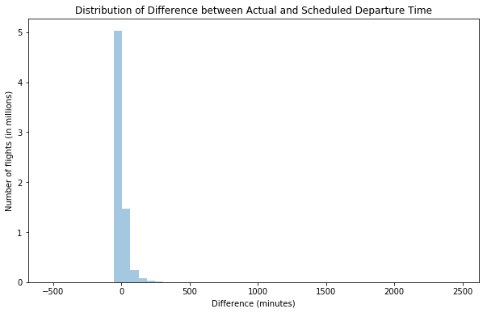

```python
plt.figure(figsize = (10, 6))
sb.distplot(departure_delay.DepDelay, kde = False)

plt.title("Distribution of Difference between Actual and Scheduled Departure Time")
plt.xlabel("Difference (minutes)")
plt.ylabel("Number of flights (in millions)")

ticks3 = np.array([n for n in range(0, 6)])
plt.yticks(ticks3*1e6, ticks3);
```

```python
departure_delay.DepDelay.min(), departure_delay.DepDelay.max()
```

```
(-534.0, 2467.0)
```

```python
departure_delay[departure_delay.DepDelay < -90.0]
```

[output not shown]

As shown above, there appears to be huge outliers for flights leaving earlier than 90 minutes than the scheduled departure time, and flights that leave over 120 minutes later than scheduled.

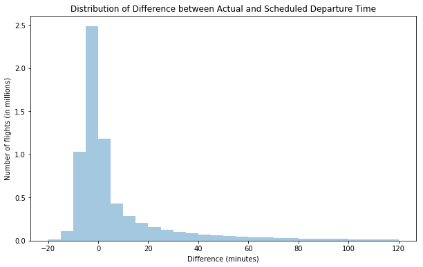

```python
# Bins are cut into 5-minute intervals
bin_edges = [i for i in range(-20, 121, 5)]
plt.figure(figsize = (10, 6))
sb.distplot(departure_delay.DepDelay, bins = bin_edges, kde = False)

plt.title("Distribution of Difference between Actual and Scheduled Departure Time")
plt.xlabel("Difference (minutes)")
plt.ylabel("Number of flights (in millions)")

ticks4 = np.array([n/2 for n in range(0, 6)])
plt.yticks(ticks4*1e6, ticks4);
```

Looking at the distribution, it follows a postive (right skew), wth the majority of flights leaving around the time of scheduled depature time. The peak lies between -5 and 0 minutes of depature delay, suggesting that many flights leave slightly earlier than scheduled. As the difference in the actual and scheduled depatrue time increases, the number of flights that fall into these bins decreases.

Another plot that can represent additional information, such as lower quartile, median, upper quartile, and range can be represented by a boxplot. As it contains many outliers, we will only look at the boxplot of the main section of interest.

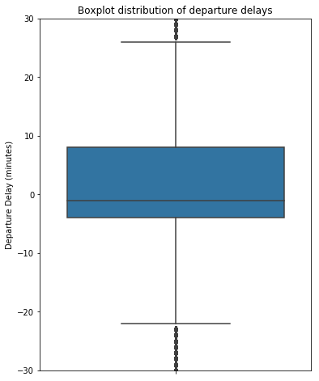

```python
plt.figure(figsize = (6, 8))
sb.boxplot(data = departure_delay, y = "DepDelay")
plt.ylim([-30, 30])
plt.title("Boxplot distribution of departure delays")
plt.ylabel("Departure Delay (minutes)");
```

From the boxplot, it confirms that the distribution is a postive (right) skew. The median lies just below 0 minutes which indicate that more than 50% of flights depart earlier than the scheduled time of flight. Furthermore, 75% of flight depart within less than 10 minutes of scheduled time flight.

#### `ArrDelay`

**What is the distribution of the difference between actual and scheduled arrival time?**

```python
# First remove the flights that have NaN values
arrival_delay = f2008_clean[f2008_clean.ArrDelay.notnull()]
```

Below, outliers will already be taken into consideration and removed to view the distribtion, similar to `DepDelay`.

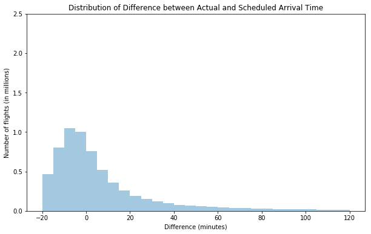

```python
plt.figure(figsize = (10, 6))
sb.distplot(arrival_delay.ArrDelay, bins = bin_edges, kde = False)

plt.title("Distribution of Difference between Actual and Scheduled Arrival Time")
plt.xlabel("Difference (minutes)")
plt.ylabel("Number of flights (in millions)")
plt.yticks(ticks4*1e6, ticks4);
```

The distribution follows a distribution with a positive (right) skew, similar to the previous section on `DepDelay`. However, there is no real well-defined peak, with the actual arrival delay time more spread out rather than being focussed within a 5 minute interval bins as with the previous plot. We can also represent this information with a violinplot.

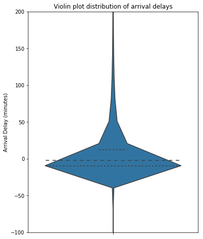

```python
plt.figure(figsize = (6, 8))
sb.violinplot(data = arrival_delay, y = "ArrDelay", inner = "quartile")
plt.ylim([-100, 200])
plt.title("Violin plot distribution of arrival delays")
plt.ylabel("Arrival Delay (minutes)");
```

The distribution for `ArrDelay` is positive (right skew) although not as pronounced as in `DepDelay`. The median lies roughly at 0 minutes so around 50% of flight arrive on time or earlier.

To compare the distribution between `ArrDelay` and `DepDelay`, the next section (bivariate exploration) will explore this further.

#### `CRSDepTime`

**Are there more flights scheduled at a particular hour of the day?**

```python
f2008_clean.CRSDepTime[0:5]
```

```
0    1955
1    0735
2    0620
3    0930
4    1755
Name: CRSDepTime, dtype: object
```

```python
# Extract just the hours
hour = f2008_clean.CRSDepTime.astype(str).str[:2]
hour.value_counts()
```

```
06    504061
07    481275
08    481092
13    463748
11    461657
09    458725
17    457092
16    455096
10    447779
12    437126
14    432680
15    420026
18    416250
19    395470
20    271335
21    246521
22     85488
05     48436
23     31867
00      8877
01      2836
04       933
02       818
03       540
Name: CRSDepTime, dtype: int64
```

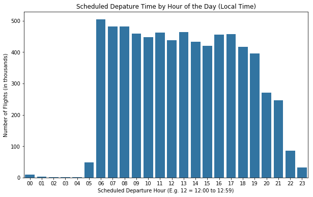

```python
plt.figure(figsize = (10, 6))
sb.countplot(hour, color = base_color)

plt.title("Scheduled Depature Time by Hour of the Day (Local Time)")
plt.xlabel("Scheduled Departure Hour (E.g. 12 = 12:00 to 12:59)")
plt.ylabel("Number of Flights (in thousands)")
ticks5 = np.array([n for n in range(0, 600, 100)])
plt.yticks(ticks5*1000, ticks5);
```

This plot shows an interesting insight. Very few flights are scheduled between 23:00 and 5:59, with the fewest between 01:00 and 04:59. From 6:00 to 17:59, the number of flights scheduled are high, with 6:00 to 8:59 being the highest. Then from 17:59 the number of flights start to drop off sequentially.

#### `AirTime`

**What is the distribution of the duration of the aircraft in air?**

Before continuing, we find that some flights have NaN values of AirTime. They are associated with cancelled or diverted flights and will be ignored in this analysis.

```python
# DF continuing all flights with a valid AirTime
airtime2008 = f2008_clean[f2008_clean.AirTime.notnull()]
```

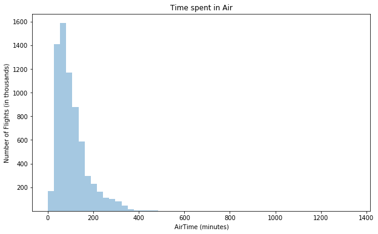

```python
# AirTime is a quantitative variable, so a histogram is appropriate
plt.figure(figsize = (10, 6))
sb.distplot(airtime2008.AirTime, kde = False)

plt.title("Time spent in Air")
plt.xlabel("AirTime (minutes)")
plt.ylabel("Number of Flights (in thousands)")
ticks6 = np.array([n for n in range(200, 1700, 200)])
plt.yticks(ticks6*1000, ticks6);
```

```python
f2008_clean[f2008_clean.AirTime > 400].Origin_city.value_counts()
```

```
Honolulu             3400
Dallas-Fort Worth    1096
Chicago               873
Houston               848
Atlanta               741
Denver                490
Newark                398
Minneapolis           365
Kahului               273
Kailua/Kona           221
Boston                129
San Juan              124
New York               84
Covington              65
Anchorage              44
Phoenix                31
Miami                  16
Salt Lake City         16
Los Angeles            15
Philadelphia            8
Las Vegas               7
Seattle                 6
Lihue                   3
Detroit                 2
Sacramento              2
Orlando                 2
San Diego               1
Islip                   1
San Jose                1
Name: Origin_city, dtype: int64
```

When `AirTime` is plotted without outliers (above 400 minutes), the following histogram is obtained.

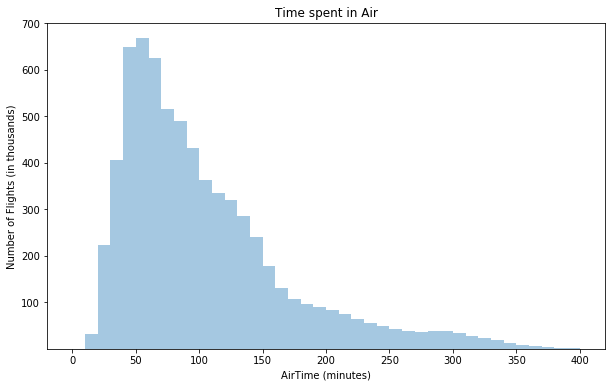

```python
# Plot without outliers.
bin_edges = [num for num in range(0, 401, 10)]
plt.figure(figsize = (10, 6))

sb.distplot(airtime2008.AirTime, kde = False, bins = bin_edges)
plt.title("Time spent in Air")
plt.xlabel("AirTime (minutes)")
plt.ylabel("Number of Flights (in thousands)")
ticks7 = np.array([n for n in range(100, 800, 100)])
plt.yticks(ticks7*1000, ticks7);
```

The histogram shows that `AirTime` follows a positive (right) skew distribution, with peaks at around 50-70 minutes. This indicates that flights within the US tend to be short, with majority of flights taking less than 2.5 hours.

#### `Distance`

**What is the distribution of distances travelled by aircrafts?**

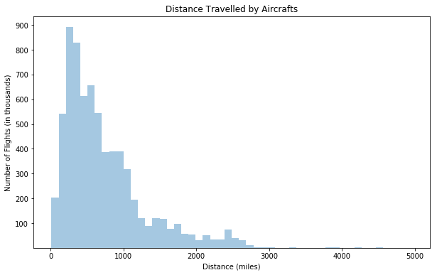

```python
# Distance is a quantitative variable, so a histogram is appropriate
plt.figure(figsize = (10, 6))
sb.distplot(f2008_clean.Distance, kde = False)

plt.title("Distance Travelled by Aircrafts")
plt.xlabel("Distance (miles)")
plt.ylabel("Number of Flights (in thousands)")
ticks8 = np.array([n for n in range(100, 1000, 100)])
plt.yticks(ticks8*1000, ticks8);
```

```python
f2008_clean[f2008_clean.Distance > 3000].Origin_city.value_counts()
```

```
Honolulu             3806
Dallas-Fort Worth    1251
Houston               908
Chicago               862
Atlanta               752
Denver                620
Anchorage             565
Kahului               529
Minneapolis           366
Newark                362
Kailua/Kona           266
San Juan              144
Los Angeles           144
Covington              90
Lihue                  45
Name: Origin_city, dtype: int64
```

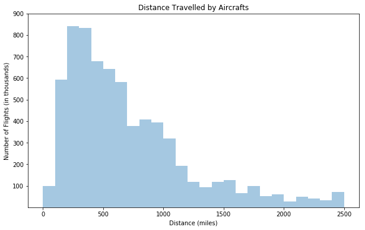

```python
bin_edges2 = [num for num in range(0, 2501, 100)]
plt.figure(figsize = (10, 6))

sb.distplot(f2008_clean.Distance, kde = False, bins = bin_edges2)
plt.title("Distance Travelled by Aircrafts")
plt.xlabel("Distance (miles)")
plt.ylabel("Number of Flights (in thousands)")
plt.yticks(ticks8*1000, ticks8);
```

`AirTime` appears to be correlated with `Distance` as we would expect. The distribution for distances contain peaks between 200 and 400 miles.

#### `Cancelled` and `Cancellation Reasons`

**What is the proportion of flights cancelled?**

```python
sorted_cancelled = f2008_clean.Cancelled.value_counts()
prop_cancelled = sorted_cancelled.values[1]/sum(sorted_cancelled.values)*100
prop_completed = 100 - prop_cancelled
```

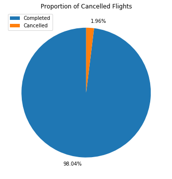

```python
# Plotting pie chart showing the proportion of flights cancelled
plt.figure(figsize = [6, 6])
plt.pie(sorted_cancelled, startangle = 90,
        labels = ['{:.2f}%'.format(prop_completed), '{:.2f}%'.format(prop_cancelled)])

plt.title("Proportion of Cancelled Flights")
plt.legend(labels = ["Completed", "Cancelled"], loc = 2);
```

Around 1.96% of flights are cancelled, or roughly one in fifty flights.

**What are the reasons for cancellations?**

The following definitions for reasons for cancellations of flights are from [this website](https://www.bts.gov/topics/airlines-and-airports/understanding-reporting-causes-flight-delays-and-cancellations).

- **Carrier**: The cause of the cancellation or delay was due to circumstances within the airline's control (e.g. maintenance or crew problems, aircraft cleaning, baggage loading, fueling, etc.).
- **Weather**: Significant meteorological conditions (actual or forecasted) that, in the judgment of the carrier, delays or prevents the operation of a flight such as tornado, blizzard or hurricane.
- **National Aviation System (NAS)**: Delays and cancellations attributable to the national aviation system that refer to a broad set of conditions, such as non-extreme weather conditions, airport operations, heavy traffic volume, and air traffic control.
- **Security**: Delays or cancellations caused by evacuation of a terminal or concourse, re-boarding of aircraft because of security breach, inoperative screening equipment and/or long lines in excess of 29 minutes at screening areas.

For delays analysis later on, the following definition will be useful.

- **Late-arriving aircraft**: A previous flight with same aircraft arrived late, causing the present flight to depart late.

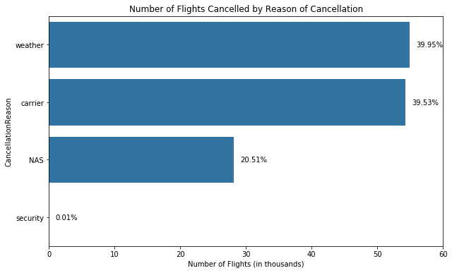

```python
cancellation_reason = f2008_clean.CancellationReason.value_counts()

plt.figure(figsize = (10, 6))
sb.countplot(data = f2008_clean, y = "CancellationReason", order = cancellation_reason.index,
            color = base_color)
plt.title("Number of Flights Cancelled by Reason of Cancellation")
plt.xlabel("Number of Flights (in thousands)")
ticks14 = np.array([n for n in range(0, 70, 10)])
plt.xticks(ticks14*1000, ticks14)


for i in range(cancellation_reason.shape[0]):
    count = cancellation_reason[i]
    percentage = '{:0.2f}%'.format(count/sum(cancellation_reason) * 100)
    plt.text(count + 1000, i, percentage, va = "center");
```

Up to 80% of cancellation of flights are split roughly evenly between the weather and the airline carrier. There are very few cancellations due to security reasons.

#### `Diverted`

**What is the proportion of flights diverted?**

```python
sorted_diverted = f2008_clean.Diverted.value_counts()
diverted_prop = f2008_clean.Diverted.value_counts()[1]/sum(f2008_clean.Diverted.value_counts())*100
notdiverted_prop = 100 - diverted_prop
```

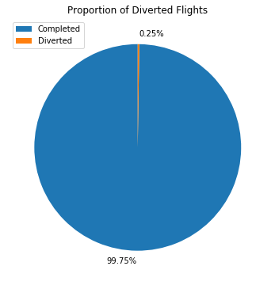

```python
plt.figure(figsize = [6, 6])
plt.pie(sorted_diverted, startangle = 90,
        labels = ['{0:.2f}%'.format(notdiverted_prop), '{0:.2f}%'.format(diverted_prop)])

plt.title("Proportion of Diverted Flights")
plt.legend(labels = ["Completed", "Diverted"], loc = 2);
```

Compared with cancelled flights, the proportion of diverted flights is even lower at 0.25%.

#### `Airline`

Which airline has the most and least flights scheduled?

```python
airline_counts = f2008_clean.Airline.value_counts()
airline_counts[0:5]
```

```
Southwest Airlines Co.          1201754
American Airlines Inc.           604885
Skywest Airlines Inc.            567159
American Eagle Airlines Inc.     490693
US Airways Inc.                  453589
Name: Airline, dtype: int64
```

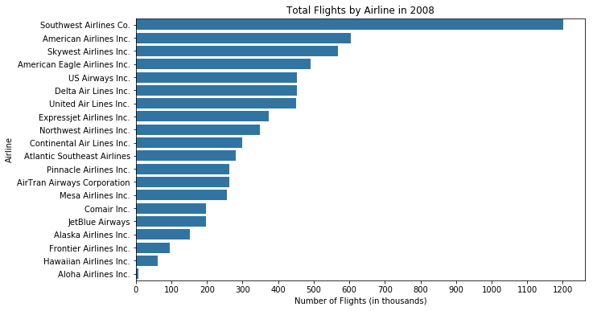

```python
plt.figure(figsize = (10, 6))
sb.countplot(data = f2008_clean, y = "Airline",
             order = airline_counts.index, color = base_color)

plt.title("Total Flights by Airline in 2008")
plt.xlabel("Number of Flights (in thousands)")
ticks9 = np.array([n for n in range(0, 1300, 100)])
plt.xticks(ticks9*1000, ticks9);
```

Southwest Airlines Co. is by far the airline with the most flights scheduled, almost double the second highest (American Airlines Inc.). On the other extreme, Aloha Airlines Inc. has scheduled by far the least number of flights.

#### `Origin_city`

**What are the top 10 cities with the most flights scheduled to take off?**

```python
top10_cities = f2008_clean.Origin_city.value_counts()[0:10]
top10_cities
```

```
Chicago              437999
Atlanta              414513
Dallas-Fort Worth    281281
Denver               241443
Houston              241105
New York             237939
Los Angeles          215608
Phoenix              199408
Las Vegas            172876
Detroit              161989
Name: Origin_city, dtype: int64
```

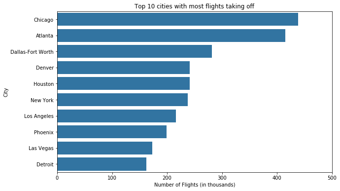

```python
plt.figure(figsize = (10, 6))
sb.barplot(y = top10_cities.index, x = top10_cities.values, color = base_color)
plt.title("Top 10 cities with most flights taking off")
plt.xlabel("Number of Flights (in thousands)")
plt.ylabel("City")
ticks10 = np.array([n for n in range(0, 600, 100)])
plt.xticks(ticks10*1000, ticks10);
```

The top 3 cities are Chicago, Atlanta, and Dallas-Fort Worth. The top 10 cities have each over 160,000 flights departed in 2008.

#### `Origin_state`

**What are the top 3 states with the most flights scheduled to take off? What are the top 3 states with the least flights scheduled to take off?**

```python
origin_states_top3 = f2008_clean.Origin_state.value_counts()[0:3]
origin_states_bot3 = f2008_clean.Origin_state.value_counts()[-3:]
```

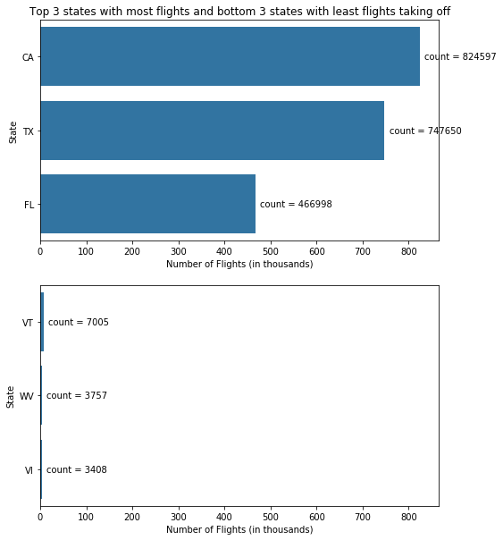

```python
# Plotting two figures one on top of another
plt.figure(figsize = (8, 10))

ax1 = plt.subplot(211)
sb.barplot(y = origin_states_top3.index, x = origin_states_top3.values, color = base_color)
plt.title("Top 3 states with most flights and bottom 3 states with least flights taking off")
plt.xlabel("Number of Flights (in thousands)")
plt.ylabel("State")
ticks11 = np.array([n for n in range(0, 900, 100)])
plt.xticks(ticks11*1000, ticks11);

# Add count to each bar
for i in range(origin_states_top3.shape[0]):
    count = origin_states_top3[i]
    plt.text(count + 10000, i, "count = " + str(count), va = "center")

ax2 = plt.subplot(212, sharex = ax1)
sb.barplot(y = origin_states_bot3.index, x = origin_states_bot3.values, color = base_color)
plt.xlabel("Number of Flights (in thousands)")
plt.ylabel("State")
plt.xticks(ticks11*1000, ticks11);

for i in range(origin_states_bot3.shape[0]):
    count = origin_states_bot3[i]
    plt.text(count + 10000, i, "count = " + str(count), va = "center")
```

As shown above, California, Texas, and Florida are the top three states (in descending order) with the most flights scheduled. On the other end of the spectrum, Vermont, West Virginia, and United States Virgin Islands have the least number of flights (in descending order).

### Analysis and Insights of Univariate Exploration

Jump back to Univariate Visualisations

Of the features you investigated, some of the data needed to be tidied, adjusted, or changed:

The following interesting insights have been found:

- **Number of Flights by `Day`**
  - The number of flights follows a spike drop pattern with certain days experiencing a huge drop, and appearing in regular intervals. This drop is investigated further on what day of the week experiences a lower number of flights. In addition, there is a particular sharp drop on 27 November 2008. After googling, there does not appear any significant event that would explain this drop.
  - Plotting the 7-day moving average does not reveal any particular pattern. It can be seen that in February there is a slight dip before rising and staying fairly constant between March and May. The peaks in the number of flights are in July and August, and towards the end of August and beginning of September, there is a noticeable significant fall in the number of flights.
- **`Month`**
  - The months with the most flights scheduled are July, March, and August. Why are there more flights in these months? July and August are holiday periods for schools and many employees from businesses go on holidays, so this could explain the higher number of flights.
  - Also it turns out that in 2008, Easter falls on 23 March so could this be a reason for more people going on vacation so therefore more flights being scheduled?
  - The month with the least flight scheduled is November. The difference between the lowest and highest number (July) of flights scheduled by month is almost 100,000 flights or around 17% lower.
  - Interestingly, December has the third least number flights scheduled. Perhaps during festive periods and pre New Year, many families may prefer to celebrate with one another?
- **`DayOfWeek`**
  - During the weekdays (Mondays to Fridays), the number of flights scheduled are very similar. On the weekends (Saturdays and Sundays), the number of flights are unusually lower, with Saturdays experiencing a significant dip (up to 17% lower compared with the average weekday).
  - This is rather unexpected as we may have expected a higher number of flights during weekends where people are more likely to go on short weekend holiday nearby. However, this is not the case. Could the higher volume of flights during weekdays be due to the increased travels of businessmen and businesswomen during weekdays, and very little on the weekends? Or could this be due to airlines which may set higher prices on the weekends, therefore lowering the demand and schedule fewer flights?
  - In addition, the lower number of flights on Saturday may be contributing to the steep drop seen from the first visualisation of number of flights by day.
- **`DepDelay`** and **`ArrDelay`**
  - the difference between actual and scheduled departure/arrival time follows a positive (right) skew with just over 50% of flights departing and arriving before the scheduled time.
  - A positive skew may come from the vast majority of flights departing and arriving close to the expected time, with many more outliers located towards the higher end due to the uncertainty in timings from delays. On the other hand, generally we would not expect flights to depart or arrive significantly earlier than scheduled.
- **`CRSDepTime`**
  - Very few flights are scheduled between 23:00 and 5:59, with the fewest between 01:00 and 04:59. Could the lack of the number of flights between 23:00 and 5:59 be due to the poor visibility at night compared with during the day? Or could this be due to lack of demand of passengers for flights late at night and before dawn?
  - From 6:00 to 17:59, the number of flights scheduled are high, with 6:00 to 8:59 being the highest. Then from 17:59 the number of flights start to drop off sequentially. Could the prime time for businessmen and businesswomen to travel to work by plane at the early hours of the morning arriving at work before 9:00?
- **`AirTime`** and **`Distance`**
  - The time of aircraft in air in US routes follows a positive (right) skew distribution, with peaks at around 50-70 minutes. Flight times tend to be short, with majority of time in air taking less than 2.5 hours.
  - AirTime appears correlated with Distance as we would expect. The further away the airports, the higher the time in air. The distribution for distances contain peaks between 200 and 400 miles.
- **`Cancelled`** and **`CancellationReason`**
  - About 1.96% (or one in 51) of flights are cancelled in 2008.
  - The main reasons for cancellations are due to airline carrier or weather, each occurring around 40% of the cancellations. This is followed by National Aviation System (NAS) at around 20%. Very few flights are cancelled due to security reasons.
- **`Diverted`**
  - About 0.25% (one in 400) of flights are diverted in 2008.
- **`Airline`**
  - Southwest Airlines Co. have by far the most scheduled flights (over 1.2 million), and almost double the number of the second highest.
  - Aloha Airlines Inc. has scheduled by far the least number of flights (7,800).
- **`Origin_city`**
  - The top three cities with the highest number of scheduled departure flights are Chicago, Atlanta, and Dallas-Fort Worth.
  - According to [Wikipedia](https://en.wikipedia.org/wiki/List_of_United_States_cities_by_population), Chicago, Atlanta, and Dallas-Fort Worth are 3rd, 37th, and 9th most populous city in the US. New York has the highest population but is 6th on the list above. It appears that the there is no correlation between the population and number of flights.
- **`Origin_state`**
  - California, Texas, and Florida are the top three states with the highest number of scheduled departure flights. According to [Wikipedia](https://simple.wikipedia.org/wiki/List_of_U.S._states_by_population), California, Texas, and Florida are the top three states with the highest population.
  - The three states with the lowest number of flights are United States Virgin Islands, West Virginia, and Vermont. US Virgin Islands and Vermont are indeed states with one of the lowest population, although West Virginia is 38th most populous.
  - This observation suggest that there could be a correlation between the population of the states and the number of flights scheduled.

## Bivariate Exploration

In bivariate exploration, the relationships between two variables are explored. Firstly, a **correlation matrix** will be plotted to provide an overview and potential interesting correlation between each pair of quantitative variables.

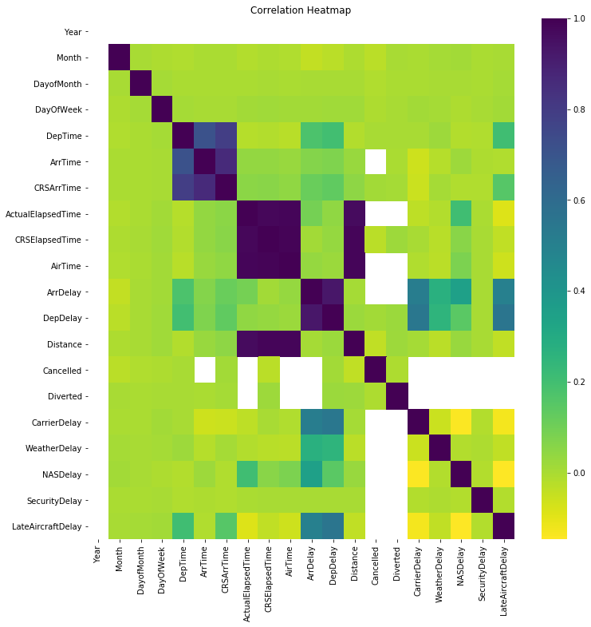

```python
plt.figure(figsize = (12, 12))
sb.heatmap(f2008_clean.corr(), cmap = "viridis_r")
plt.title("Correlation Heatmap");
```

From the correlation heatmap, there appears to several groups of variables which have strong positive correlation with one another. These are:

- `DepTime`, `ArrTime`, and `CRSArrTime` (Pearson correlation coefficient r > 0.6)
- `ActualElapsedTime`, `CRSElapsedTime`, and `AirTime` (r close to 1)
- `DepDelay` and `ArrDelay` (r > 0.8)

In addition, `Distance` appears to be strongly correlated with `ActualElapsedTime`, `CRSElapsedTime`, and `AirTime` as we would expect. Furthemore, most type of delays (apart from `SecurityDelay`) appear to have a weak postive correlation with `ArrDelay` and `DepDelay`.

In this section of bivariate exploration, the year **2008** will be explored. There will be one visual comparing the different years. First, the visualisations to each question along with comments on it will be given. Then at the end of the section, interesting insights, interpretations and questions will be provided.

1. `Month` and `Cancelled` - are there particular months where more flights are cancelled?
2. `Month` and `CancellationReason` - are there particular months where more flights are cancelled for a particular reason?
3. `ActualElapsedTime` and `CRSElapsedTime` - what is the distribution of the differences between actual elapsed time and scheduled elapsed time of flight?
4. `DepDelay` and `ArrDelay` - how are the depature and arrival delays distributed?
5. `AirTime` and `Distance` - how closely do time in the air and distance travelled correlate?
6. `Distance` and `Airline` - do certain airlines favour short-haul or long-haul flights?
7. `Airline` and `CarrierDelay` - are there certain airlines where more delays occur due to carrier delay?
8. `Airline` and `LateAircraftDelay` - are there certain airlines where more delays occur due to late aircraft arrival?
9. `Origin_city` and `WeatherDelay` - are there certain departure cities where more delays occur due to the weather?

Jump to Bivariate Insights and Interpretations

#### `Month` and `Cancelled`

**Are there particular months where more flights are cancelled?**

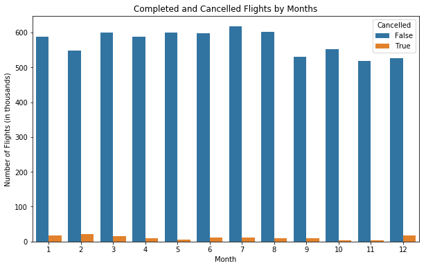

```python
# Month and Cancelled are both qualitative variables so a clustered bar chart is appropriate
plt.figure(figsize = (10, 6))
sb.countplot(data = f2008_clean, x = "Month", hue = "Cancelled")
plt.title("Completed and Cancelled Flights by Months")
plt.ylabel("Number of Flights (in thousands)")
ticks12 = np.array([n for n in range(0, 700, 100)])
plt.yticks(ticks12*1000, ticks12);
```

The plot above does not give a good indication whether there is a relationship between month and cancelled flights. Rather than looking at the absolute number of completed and cancelled flights, the proportions of cancelled flights may be better.

```python
cancelled_month = f2008_clean.groupby("Month").Cancelled.sum()
total_month = f2008_clean.groupby("Month").Cancelled.count()
cancelled_prop = cancelled_month/total_month
cancelled_prop
```

```
Month
1     0.028572
2     0.036182
3     0.026267
4     0.017312
5     0.010274
6     0.017959
7     0.016878
8     0.016063
9     0.018327
10    0.005841
11    0.008519
12    0.032625
Name: Cancelled, dtype: float64
```

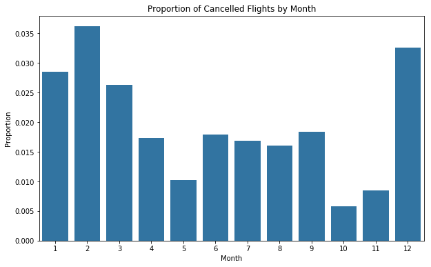

```python
plt.figure(figsize = (10, 6))
sb.barplot(cancelled_prop.index, cancelled_prop.values, color = base_color)
plt.title("Proportion of Cancelled Flights by Month")
plt.ylabel("Proportion");
```

Above shows the proportion of flights cancelled in 2008 is highest in February, December and January (in that order), and lowest in October and November (in ascending order). Perhaps looking at `CancellationReason` by `Month` could provide further insights.

#### `Month` and `CancellationReason`

Are there particular months where more flights are cancelled for a particular reason?

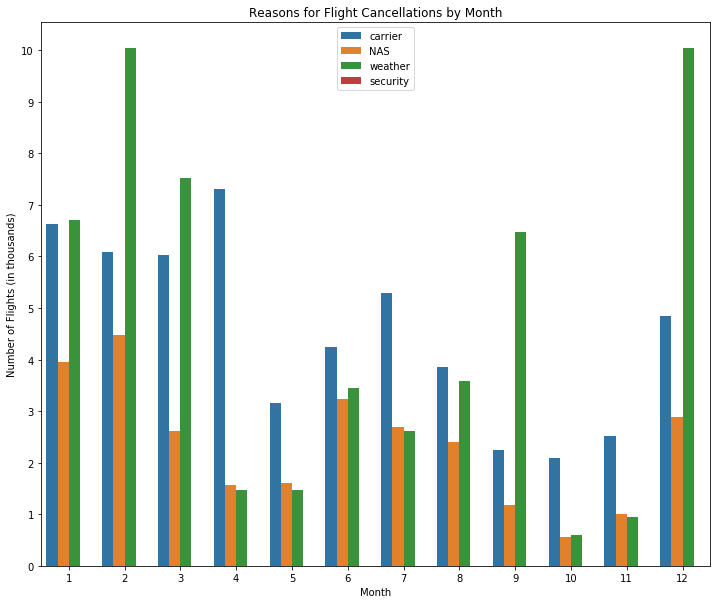

```python
plt.figure(figsize = (12, 10))
sb.countplot(data = f2008_clean, x = "Month", hue = "CancellationReason")
plt.title("Reasons for Flight Cancellations by Month")
plt.ylabel("Number of Flights (in thousands)")
plt.legend(loc = 9)
ticks13 = np.array([n for n in range(0, 11)])
plt.yticks(ticks13*1000, ticks13);
```

Interestingly, for February and December (the two months with highest number of cancellations) the main reason for cancellations are due to bad weather. January (the third highest number of cancellations) has a fairly similar number of cancellations due to weather and carrier, with both numbers still high. There are very very few cancellations due to security reasons.

#### `ActualElapsedTime` and `CRSElapsedTime`

**What is the distribution of the actual elapsed time and scheduled elapsed time of flight?**

```python
# upper and lower bound of elapsed time
lower = min(f2008_clean.ActualElapsedTime.min(), f2008_clean.CRSElapsedTime.min()).astype(int)
upper = max(f2008_clean.ActualElapsedTime.max(), f2008_clean.CRSElapsedTime.max()).astype(int)
(lower, upper)
```

```
(-141, 1435)
```

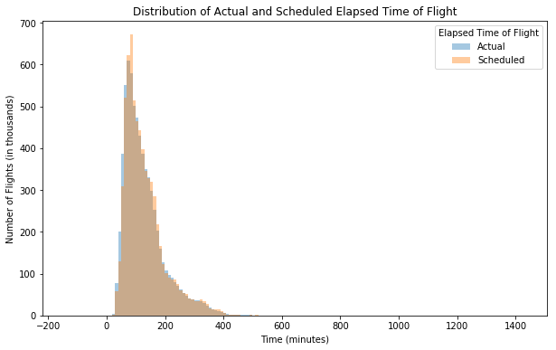

```python
bin_edges = [n for n in range(lower, upper, 10)]
plt.figure(figsize = (10, 6))
sb.distplot(elapsed_time.ActualElapsedTime, kde = False, label = "Actual", bins = bin_edges)
sb.distplot(elapsed_time.CRSElapsedTime, kde = False, label = "Scheduled", bins = bin_edges)

plt.title("Distribution of Actual and Scheduled Elapsed Time of Flight")
plt.xlabel("Time (minutes)")
plt.ylabel("Number of Flights (in thousands)")
ticks15 = np.array([n for n in range(0, 800, 100)])
plt.yticks(ticks15*1e3, ticks15)
plt.legend(title = "Elapsed Time of Flight");
```

To see the distribution more clearly, outliers (less than zero minutes and greater than 400 minutes) will be removed.

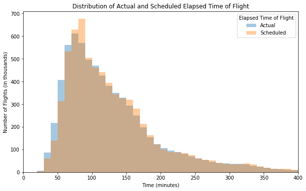

```python
bin_edges = [n for n in range(0, 401, 10)]
plt.figure(figsize = (10, 6))
sb.distplot(elapsed_time.ActualElapsedTime, kde = False, label = "Actual", bins = bin_edges)
sb.distplot(elapsed_time.CRSElapsedTime, kde = False, label = "Scheduled", bins = bin_edges)

plt.title("Distribution of Actual and Scheduled Elapsed Time of Flight")
plt.xlabel("Time (minutes)")
plt.ylabel("Number of Flights (in thousands)")
ticks15 = np.array([n for n in range(0, 701, 100)])
plt.yticks(ticks15*1e3, ticks15)
plt.legend(title = "Elapsed Time of Flight")
plt.xlim([0, 400]);
```

The distribution of both actual and scheduled elapsed time are very similar, with a weak positive (right) skew, peaking between 70 and 90 minutes.

#### `DepDelay` and `ArrDelay`

**How are the departure and arrival delays distributed?**

Would you expect a very similar distribution for departure and arrival delays or will it be different? If it is the latter, how will it be different?

```python
# DF containing non-null values for departure and arrival delays
dep_arr_delay = f2008_clean[f2008_clean.DepDelay.notnull()]
dep_arr_delay = dep_arr_delay[dep_arr_delay.ArrDelay.notnull()]
```

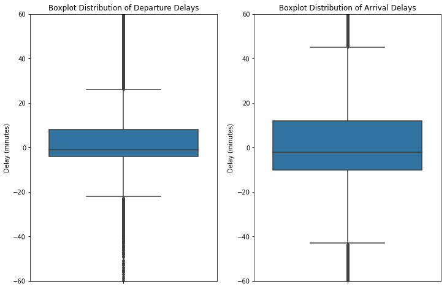

```python
plt.figure(figsize = (12, 8))

plt.subplot(121)
sb.boxplot(data = dep_arr_delay, y = "DepDelay")
plt.ylim([-60, 60])
plt.title("Boxplot Distribution of Departure Delays")
plt.ylabel("Delay (minutes)");

plt.subplot(122)
sb.boxplot(data = dep_arr_delay, y = "ArrDelay")
plt.ylim([-60, 60])
plt.title("Boxplot Distribution of Arrival Delays")
plt.ylabel("Delay (minutes)");
```

From the plot above, we can see that the interquartile range IQR (upper minus lower quartile) is larger for arrival delays. As shown below using the "describe" method, the IQR for departure delay is 12 minutes compared with arrival delay of 22 minutes. Consequently, the range (excluding outliers) are also significantly higher. The median for both departure and arrival delays are fairly similar at -1 and -2 minutes, respectively. Both contain many outliers indicated by points beyond the T-shaped lines which are connected above and below the box.

```python
dep_arr_delay[["DepDelay", "ArrDelay"]].describe()
```

|  | DepDelay | ArrDelay |
| --- | --- | --- |
| count | 6.855029e+06 | 6.855029e+06 |
| mean | 9.923845e+00 | 8.168452e+00 |
| std | 3.520386e+01 | 3.850194e+01 |
| min | -5.340000e+02 | -5.190000e+02 |
| 25% | -4.000000e+00 | -1.000000e+01 |
| 50% | -1.000000e+00 | -2.000000e+00 |
| 75% | 8.000000e+00 | 1.200000e+01 |
| max | 2.467000e+03 | 2.461000e+03 |

#### `AirTime` and `Distance`

**How closely do time in the air and distance travelled correlate?**

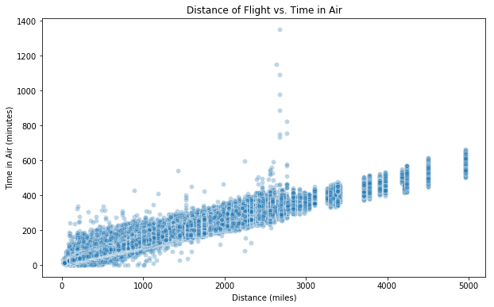

```python
plt.figure(figsize = (10, 6))
sb.scatterplot(data = f2008_clean, x = "Distance", y = "AirTime", alpha = 0.3)
plt.title("Distance of Flight vs. Time in Air")
plt.xlabel("Distance (miles)")
plt.ylabel("Time in Air (minutes)");
```

There appears to be a thick positive upward sloping line that suggest what is expected - the further the distance between the origin and destination, the greater the time in air. However, there are quite a few flights which do not lie in this thick band. In particular, the points at a distance 2700-2800 miles which form an almost vertical line suggest that the time in flight varies hugely. This is explored below.

```python
f2008_clean[f2008_clean.AirTime > 700]
```

[output not shown]

#### `Distance` and `Airline`

**Do certain airlines favour short-haul or long-haul flights?**

To address this question, the distribution of distance of flights made by each airline will be created.

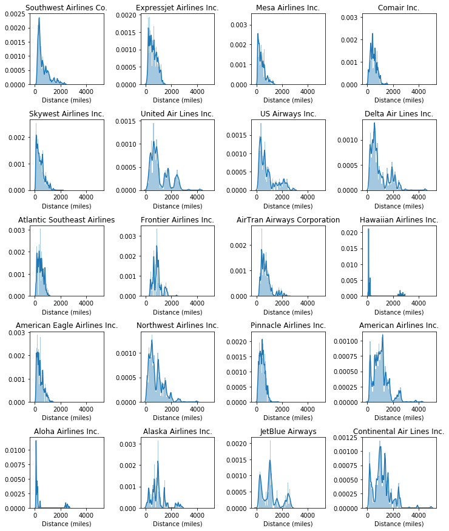

```python
airlines = f2008_clean.Airline.unique()
location = [i for i in range(1, 21)]

fig = plt.figure(figsize = (12, 15))

# Share axes with plot with highest values on axis
ax3 = plt.subplot(5, 4, 20)

# Create space between plots
fig.subplots_adjust(wspace = 0.5, hspace = 0.5)

for airline, loc in zip(airlines, location):
    ax = plt.subplot(5, 4, loc, sharex = ax3)
    airline_plot = f2008_clean[f2008_clean.Airline == airline]
    sb.distplot(airline_plot.Distance)
    plt.title(airline)
    plt.xlabel("Distance (miles)");
```

```python
hawaii = f2008_clean[f2008_clean.Airline == "Aloha Airlines Inc."]
hawaii["Origin_city"].value_counts()
```

```
Honolulu       3215
Kahului        1348
Lihue          1000
Kailua/Kona     891
Hilo            532
Santa Ana       303
Oakland         184
Sacramento      118
San Diego        89
Las Vegas        60
Reno             60
Name: Origin_city, dtype: int64
```

#### `Airline` and `CarrierDelay`

**Are there certain airlines where more delays occur due to carrier delay?**

First, the total delay time due to carrier delay will be computed for each airline.

```python
# Groups by Airline and compute the total time delayed due to carrier delay
airline_carrier_delays = f2008_clean.groupby("Airline").CarrierDelay.sum()
airline_carrier_delays_order = airline_carrier_delays.sort_values(ascending = False)
airline_carrier_delays_order
```

```
Airline
American Airlines Inc.          2821907.0
Southwest Airlines Co.          2261002.0
Mesa Airlines Inc.              1927740.0
United Air Lines Inc.           1720150.0
American Eagle Airlines Inc.    1705271.0
Atlantic Southeast Airlines     1688969.0
Skywest Airlines Inc.           1678216.0
Northwest Airlines Inc.         1478247.0
Delta Air Lines Inc.            1411220.0
Expressjet Airlines Inc.        1218009.0
US Airways Inc.                 1109335.0
Comair Inc.                     1075766.0
Continental Air Lines Inc.       996161.0
Pinnacle Airlines Inc.           908509.0
JetBlue Airways                  677621.0
Alaska Airlines Inc.             481833.0
AirTran Airways Corporation      443708.0
Frontier Airlines Inc.           250971.0
Hawaiian Airlines Inc.           184855.0
Aloha Airlines Inc.                8727.0
Name: CarrierDelay, dtype: float64
```

Instead of calculating the total number flights delayed, it is a fairer comparison to compute the average number of minutes delayed per flight.

```python
# Compute the average number of minutes delayed
airline_count = f2008_clean.groupby("Airline").count()["Year"]
carrier_delay_prop = (airline_carrier_delays/airline_count).sort_values(ascending = False)
carrier_delay_prop
```

```
Airline
Mesa Airlines Inc.              7.561841
Atlantic Southeast Airlines     6.019670
Comair Inc.                     5.443967
American Airlines Inc.          4.665196
Northwest Airlines Inc.         4.252088
United Air Lines Inc.           3.826680
American Eagle Airlines Inc.    3.475230
Pinnacle Airlines Inc.          3.464841
JetBlue Airways                 3.455646
Continental Air Lines Inc.      3.337726
Expressjet Airlines Inc.        3.252274
Alaska Airlines Inc.            3.188793
Delta Air Lines Inc.            3.122645
Hawaiian Airlines Inc.          2.989923
Skywest Airlines Inc.           2.958987
Frontier Airlines Inc.          2.620779
US Airways Inc.                 2.445683
Southwest Airlines Co.          1.881418
AirTran Airways Corporation     1.695587
Aloha Airlines Inc.             1.118846
dtype: float64
```

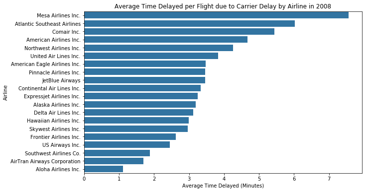

```python
plt.figure(figsize = (10, 6))
sb.barplot(y = carrier_delay_prop.index, x = carrier_delay_prop.values,
          color = base_color)
plt.title("Average Time Delayed per Flight due to Carrier Delay by Airline in 2008")
plt.xlabel("Average Time Delayed (Minutes)");
```

From this barchart, it can be shown that Mesa Airlines Inc. has the highest average time delayed per flight due to carrier delay, over 1.5 minutes higher on average compared with the second highest: Atlantic Southeast Airlines. Aloha Airlines Inc. has the lowest average time delayed.